# KNN_cas1_reseno_moja_rjesenja

```python
import numpy as np
import pandas as pd
import matplotlib.pyplot as plt
from google.colab import drive
drive.mount('/content/drive')
```

## Genersanje podataka

Generisanje podataka (dve klase, normalne raspodele u 2-D prostoru). Varirati parametre normalnih raspodela za prikaz različitih slučajeva primene KNN.

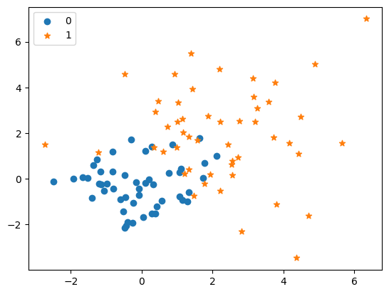

```python
X_1 = np.random.normal(0,1,size=(50,2))
X_2 = np.random.normal(2,2,size=(50,2))
X = np.concatenate((X_1,X_2), axis=0)
Y = np.concatenate((np.zeros((50,1)),np.ones((50,1))), axis=0)
plt.scatter(X[:50,0], X[:50,1], label='0', marker='o')
plt.scatter(X[50:,0], X[50:,1], label='1', marker='*')
plt.legend()
```

```python
from sklearn.model_selection import train_test_split
X_train, X_test, Y_train, Y_test = train_test_split(X, Y, test_size=0.1, random_state=10, stratify=Y)
```

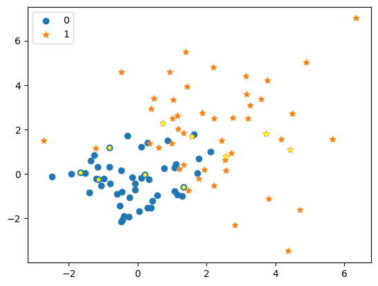

```python
plt.scatter(X[:50,0], X[:50,1], label='0', marker='o')
plt.scatter(X[50:,0], X[50:,1], label='1', marker='*')
plt.scatter(X_test[:,0], X_test[:,1], marker='.', c='yellow') #zutim su oznaceni test uzorci
plt.legend()
```

Primena KNN algoritma na generisanim podacima i poređenje pravih i dobijenih labela (oznaka klase).

```python
from sklearn.neighbors import KNeighborsClassifier

# inicijalizacija i obuka klasifikatora
classifier = KNeighborsClassifier(n_neighbors=10, metric='euclidean')
classifier.fit(X_train, Y_train)

# n_neighbors (default 5)
# weights (uniform, distance or user-defined)
# p (default 2, meaning euclidean, 1 would be manhattan)
# metric (default minkowski, sklearn.neighbors.DistanceMetric (euclidean, manhattan, chebyshev, minkowski, hamming(int), jaccard, dice))
# metric_params

# testiranje
# print(classifier)
Y_pred = classifier.predict(X_test)
print(Y_pred)
```

```
[0. 0. 1. 0. 1. 0. 1. 0. 1. 1.]
```

Vizualizacija dobijenih rezultata. Pogrešno klasifikovani uzorci imaće tačku suprotne boje.

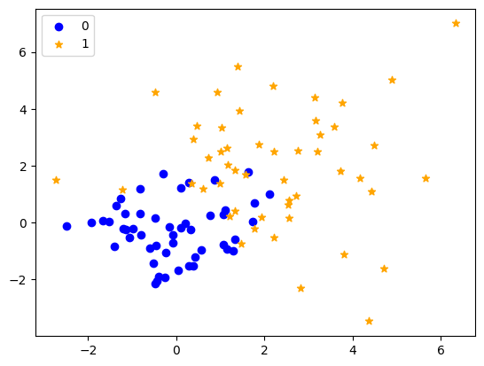

```python
##NOTE: u ovom slucaju su svi dobro klasifikovani
plt.scatter(X[:50,0], X[:50,1], label='0', marker='o', c='blue')
plt.scatter(X[50:,0], X[50:,1], label='1', marker='*', c='orange')
for i in range(len(X_test)):
  # print('Y_pred[i]=',Y_pred[i],' Y_test[i]=',Y_test[i])
  if Y_pred[i]==0:
    plt.scatter(X_test[i,0], X_test[i,1], marker='.', c='blue') ## was blue
  elif Y_pred[i]==1:
    plt.scatter(X_test[i,0], X_test[i,1], marker='.', c='orange') ## was orange
plt.legend()
##NOTE: u ovom slucaju su svi dobro klasifikovani
```

Matrica konfuzije (kolone su predviđene, a vrste su prave klase).

```python
# negativ je klasa 0, a pozitiv klasa 1
TN=0
FP=0
FN=0
TP=0

for i in range(len(Y_pred)):
  if Y_pred[i]==0 and Y_test[i]==0:
    TN = TN+1
  elif Y_pred[i]==1 and Y_test[i]==0:
    FP = FP+1
  elif Y_pred[i]==0 and Y_test[i]==1:
    FN = FN+1
  elif Y_pred[i]==1 and Y_test[i]==1:
    TP = TP+1

conf_mat = pd.DataFrame(columns=['0','1'], index=['0','1'])
conf_mat.iloc[0,0]=TN
conf_mat.iloc[0,1]=FP
conf_mat.iloc[1,0]=FN
conf_mat.iloc[1,1]=TP

conf_mat
```

|  | 0 | 1 |
| --- | --- | --- |
| 0 | 5 | 0 |
| 1 | 0 | 5 |

```python
from sklearn.metrics import confusion_matrix

conf_mat = confusion_matrix(Y_test, Y_pred) # TN, FP
print(conf_mat)                             # FN, TP
```

```
[[5 0]
 [0 5]]
```

Mere uspešnosti klasifikatora.

- $ precision = \frac{TP}{TP+FP} $
- $ accuracy = \frac{TP+TN}{TP+TN+FP+FN} $
- $ sensitivity = \frac{TP}{TP+FN} $
- $ specificity = \frac{TN}{TN+FP} $
- $ F\_score = \frac{2*precision*sensitivity}{precision+sensitivity} $

```python
precision = TP/(TP+FP)
accuracy = (TP+TN)/(TP+TN+FP+FN)
sensitivity = TP/(TP+FN)
specificity = TN/(TN+FP)
F_score = 2*precision*sensitivity/(precision+sensitivity)
print('precision: ', precision)
print('accuracy: ', accuracy)
print('sensitivity/recall: ', sensitivity)
print('specificity: ', specificity)
print('F score: ', F_score)
```

```
precision:  1.0
accuracy:  1.0
sensitivity/recall:  1.0
specificity:  1.0
F score:  1.0
```

# Zadatak 1

Implementirati algoritam za klasifikaciju ispitanika na one koji se izjašnjavaju kao srećni i one koji se ne izjašnjavaju kao srećni. Koristiti bazu podataka koja sadrži rezultate ankete od 143 osobe. U anketi se postavlja 6 pitanja u kojima se proverava koliko je anketirana osoba na skali od 1 do 5 zadovoljna sa: dostupnošću informacija o gradskim službama, visinom troškova stanovanja, kvalitetom državnog školstva, poverenjem u lokalnu policiju, održavanjem ulica i trotoara, i dostupnošću društvenih događaja. Odgovori anketirane osobe su obeležja za tu osobu i svaka osoba rekla je da li je srećna ili nije, a taj odgovor predstavlja klasnu labelu.

```python
import numpy as np
import matplotlib.pyplot as plt
import pandas as pd
```

```python
# Read dataset to pandas dataframe
!gdown 18LShd5kJch5nxHbHxYkkI_qRlrQ60WmL
```

Učitati podatke u DataFrame. Koliko ima uzoraka? Koliko ima obeležja i kog su tipa?

```python
cols = ['class', 'services', 'cost', 'schools', 'police', 'streets', 'events']
dataset = pd.read_csv('SomervilleHappinessSurvey2015.csv', encoding = "utf-16")
dataset.columns = cols
print(dataset.shape)
dataset.head()
```

```python
X = dataset.iloc[:, 1:] #obeležja
y = dataset.iloc[:, 0] #labele
```

Proveriti koliko uzoraka ima u kojoj klasi, kao i da li ima nedostajućih vrednosti.

```python
print("broj uzoraka u klasi 1 je: ", sum(y==1))
print("broj uzoraka u klasi 0 je: ", sum(y==0))
print("broj nedostajućih podataka je: ", X.isnull().sum().sum())
```

## Trostruka podela skupa

```python
from sklearn.model_selection import train_test_split

# podela podataka na trening i test
X_train, X_test, y_train, y_test = train_test_split(X, y, train_size=0.8, random_state=10, stratify=y)

# podela trening skupa na trening i validacioni
X_test, X_val, y_test, y_val = train_test_split(X_test, y_test, test_size=0.5, random_state=10, stratify=y_test)
```

Kada koristiti Hamming metriku? a = [1, 0, 1, 1] b = [1, 1, 0, 1]

Hamming distanca = (broj različitih pozicija) / (ukupan broj pozicija) = 2 / 4 = 0.5

- Kada radiš sa binarno kodiranim podacima
- Kada koristiš jedno-hot enkodirane kategorije
- Kada meriš sličnost između nizova ili vektora znakova

```python
from sklearn import metrics

# inicijalizacija i obuka klasifikatora
classifier = KNeighborsClassifier(n_neighbors=11, metric='hamming')
classifier.fit(X_train, y_train)

# validacija
y_pred = classifier.predict(X_val)
accuracy = metrics.accuracy_score(y_val, y_pred)
print(accuracy)
```

```python
# korigovanje hiperparametara i validacija
classifier = KNeighborsClassifier(n_neighbors=3, metric='hamming')
classifier.fit(X_train, y_train)

y_pred = classifier.predict(X_val)
accuracy = metrics.accuracy_score(y_val, y_pred)
print(accuracy)
```

```python
acc = []
# Racunanje greske za razlicito k, hamming metrika
for i in range(1, 21):
    classifier = KNeighborsClassifier(n_neighbors=i, metric='hamming')
    classifier.fit(X_train, y_train)
    y_pred = classifier.predict(X_val)
    acc.append(metrics.accuracy_score(y_val, y_pred))
plt.figure(figsize=(12, 6))
plt.plot(range(1, 21), acc, color='red', linestyle='dashed', marker='o')
plt.title('Postignuta tacnost za razlicito k na validacionom skupu (hamming metrika)')
plt.xlabel('broj suseda')
plt.ylabel('tacnost')
```

The Bray-Curtis distance, also known as Bray-Curtis dissimilarity, is a statistical measure used to quantify the dissimilarity between two samples, especially in ecology and biology. It is often used to compare species abundance or diversity between different sites or environments. The distance ranges from 0 to 1, where 0 indicates identical samples and 1 indicates completely dissimilar samples

```python
acc = []
# Racunanje greske za razlicito k (euklidska metrika)
for i in range(1, 21):
    classifier = KNeighborsClassifier(n_neighbors=i, metric='euclidean')
    classifier.fit(X_train, y_train)
    y_pred = classifier.predict(X_val)
    acc.append(metrics.accuracy_score(y_val, y_pred))
plt.figure(figsize=(12, 6))
plt.plot(range(1, 21), acc, color='red', linestyle='dashed', marker='o')
plt.title('Postignuta tacnost za razlicito k na validacionom skupu (euklidska metrika)')
plt.xlabel('broj suseda')
plt.ylabel('tacnost')
```

```python
acc = []
# Racunanje greske za razlicito k (braycurtis metrika)
for i in range(1, 21):
    classifier = KNeighborsClassifier(n_neighbors=i, metric='braycurtis')
    classifier.fit(X_train, y_train)
    y_pred = classifier.predict(X_val)
    acc.append(metrics.accuracy_score(y_val, y_pred))
plt.figure(figsize=(12, 6))
plt.plot(range(1, 21), acc, color='red', linestyle='dashed', marker='o')
plt.title('Postignuta tacnost za razlicito k na validacionom skupu (braycurtis metrika)')
plt.xlabel('broj suseda')
plt.ylabel('tacnost')
```

```python
# obuka konacnog modela
classifier = KNeighborsClassifier(n_neighbors=18, metric='hamming')
classifier.fit(pd.concat([X_train, X_val], axis=0), pd.concat([y_train, y_val], axis=0)) #classifier.fit(X_train1, y_train1)

# testiranje
y_pred = classifier.predict(X_test)
for i,j in zip(y_pred, y_test):
  print(i,j)
```

```python
from sklearn.metrics import confusion_matrix
conf_mat = confusion_matrix(y_test, y_pred) # TN, FP
print(conf_mat)                             # FN, TP
```

```python
precision = metrics.precision_score(y_test, y_pred)
accuracy = metrics.accuracy_score(y_test, y_pred)
sensitivity = metrics.recall_score(y_test, y_pred)
f_score = metrics.f1_score(y_test, y_pred)

print('precision: ', precision)
print('accuracy: ', accuracy)
print('sensitivity/recall: ', sensitivity)
print('F score: ', f_score)
```

```python
print(metrics.classification_report(y_test, y_pred))
```

```python
!jupyter nbconvert --to html "/content/drive/MyDrive/Colab Notebooks/KNN_cas1_reseno_moja_rjesenja.ipynb"
```